# Chapter #2: Validation Basics

```python
import numpy as np
import pandas as pd
from sklearn.ensemble import RandomForestClassifier
from sklearn.ensemble import RandomForestRegressor
from sklearn.model_selection import train_test_split, KFold, cross_val_score, RandomizedSearchCV
from sklearn.metrics import mean_absolute_error as mae
from sklearn.metrics import mean_squared_error as mse
from sklearn.metrics import confusion_matrix, accuracy_score, recall_score, precision_score, make_scorer
```

## 1. Creating train, test, and validation datasets

### 1.1. Create one holdout set

Your boss has asked you to create a simple random forest model on the `tic_tac_toe` dataset. She doesn't want you to spend much time selecting parameters; rather she wants to know how well the model will perform on future data. For future Tic-Tac-Toe games, it would be nice to know if your model can predict which player will win.

The dataset tic_tac_toe has been loaded for your use.

Note that in Python, =\ indicates the code was too long for one line and has been split across two lines.

- Getting everything ready.

```python
# Reading the data:
tic_tac_toe = pd.read_csv("./data/tic-tac-toe.csv")
```

```python
# Exploring the data shape:
tic_tac_toe.shape
```

```
(958, 10)
```

```python
# Exploring the first 5 rows:
tic_tac_toe.head()
```

|  | Top-Left | Top-Middle | Top-Right | Middle-Left | Middle-Middle | Middle-Right | Bottom-Left | Bottom-Middle | Bottom-Right | Class |
| --- | --- | --- | --- | --- | --- | --- | --- | --- | --- | --- |
| 0 | x | x | x | x | o | o | x | o | o | positive |
| 1 | x | x | x | x | o | o | o | x | o | positive |
| 2 | x | x | x | x | o | o | o | o | x | positive |
| 3 | x | x | x | x | o | o | o | b | b | positive |
| 4 | x | x | x | x | o | o | b | o | b | positive |

```python
# Encoding the target column into (0 / 1):
tic_tac_toe['Class'] = tic_tac_toe['Class'].apply(lambda x : 1 if x == 'positive' else 0)
```

```python
# Encoding the feaatures into (0 / 1):
features = [col for col in tic_tac_toe.columns if col != 'Class']
tic_tac_toe = pd.get_dummies(data=tic_tac_toe, columns=features)
```

```python
# defining a function to split the data into X & y:
def split_data(data, y_col):

    features = [col for col in data.columns if col != y_col]

    X = data[features].copy()
    y = data[y_col].copy()

    return X, y
```

- Create the `X` dataset by creating dummy variables for all of the categorical columns.

```python
# Slpitting the data into features matrix (X) & target column (y):
X, y = split_data(tic_tac_toe, 'Class')
```

- Split `X` and `y` into train (`X_train`, `y_train`) and test (`X_test`, `y_test`) datasets.
- Split the datasets using 10% for testing

```python
# Splitting the data into training & hold-out sets:
X_train, X_test, y_train, y_test  = train_test_split(X, y, test_size=0.1, random_state=1111)
```

### 1.2. Create two holdout sets

You recently created a simple random forest model to predict Tic-Tac-Toe game wins for your boss, and at her request, you did not do any parameter tuning. Unfortunately, the overall model accuracy was too low for her standards. This time around, she has asked you to focus on model performance.

Before you start testing different models and parameter sets, you will need to split the data into training, validation, and testing datasets. Remember that after splitting the data into training and testing datasets, the validation dataset is created by splitting the training dataset.

The datasets `X` and `y` have been loaded for your use.

- Create temporary datasets and testing datasets (`X_test`, `y_test`). Use 20% of the overall data for the testing datasets.

```python
# Splitting the data into temporary & hold-out sets:
X_temp, X_test, y_temp, y_test = train_test_split(X, y, test_size=0.2, random_state=1111)
```

- Using the temporary datasets (`X_temp`, `y_temp`), create training (`X_train`, `y_train`) and validation (`X_val`, `y_val`) datasets.
- Use 25% of the temporary data for the validation datasets.

```python
# Splitting the temporary dataset into training & validation sets:
X_train, X_val, y_train, y_val = train_test_split(X_temp, y_temp, test_size=0.25, random_state=1111)
```

### 1.3. Why use holdout sets

It is important to understand when you would use three datasets (training, validation, and testing) instead of two (training and testing). There is no point in creating an additional dataset split if you are not going to use it.

When should you consider using training, validation, and testing datasets?

> When testing parameters, tuning hyper-parameters, or anytime you are frequently evaluating model performance.

## 2. Accuracy metrics: regression models

### 2.1. Mean absolute error

Communicating modeling results can be difficult. However, most clients understand that on average, a predictive model was off by some number. This makes explaining the mean absolute error easy. For example, when predicting the number of wins for a basketball team, if you predict 42, and they end up with 40, you can easily explain that the error was two wins.

In this exercise, you are interviewing for a new position and are provided with two arrays. `y_test`, the true number of wins for all 30 NBA teams in 2017 and `predictions`, which contains a prediction for each team. To test your understanding, you are asked to both manually calculate the MAE and use `sklearn`.

- Getting everything ready.

```python
# Copying y_test & predictions from the workspace:
y_test = np.array([53, 51, 51, 49, 43, 42, 42, 41, 41, 37, 36, 31, 29, 28, 20,
                   67, 61, 55, 51, 51, 47, 43, 41, 40, 34, 33, 32, 31, 26, 24])

predictions = np.array([60, 62, 42, 42, 30, 50, 52, 42, 44, 35, 30, 30, 35, 40, 15,
                        72, 58, 60, 40, 42, 45, 46, 40, 35, 25, 40, 20, 34, 25, 24])
```

- Manually calculate the MAE using `n` as the number of observations predicted.

```python
# Calculating the mean absolute error manually:
mae_one = np.mean(abs(y_test - predictions))
```

- Calculate the MAE using `sklearn`.

```python
# Calculating the mean absolute error via sklearn's metric function:
mae_two = mae(y_test, predictions)
```

- Print off both accuracy values using the print statements.

```python
# Printing both:
print(f'With a manual calculation, the error is {mae_one}')
print(f'Using scikit-learn, the error is {mae_two}')
```

```
With a manual calculation, the error is 5.9
Using scikit-learn, the error is 5.9
```

### 2.2. Mean squared error

Let's focus on the 2017 NBA predictions again. Every year, there are at least a couple of NBA teams that win way more games than expected. If you use the MAE, this accuracy metric does not reflect the bad predictions as much as if you use the MSE. Squaring the large errors from bad predictions will make the accuracy look worse.

In this example, NBA executives want to better predict team wins. You will use the mean squared error to calculate the prediction error. The actual wins are loaded as `y_test` and the predictions as `predictions`.

- Getting everything ready.

```python
# Copying y_test & predictions from the workspace:
y_test = np.array([53, 51, 51, 49, 43, 42, 42, 41, 41, 37, 36, 31, 29, 28, 20,
                   67, 61, 55, 51, 51, 47, 43, 41, 40, 34, 33, 32, 31, 26, 24])

predictions = np.array([60, 62, 42, 42, 30, 50, 52, 42, 44, 35, 30, 30, 35, 40, 15,
                        72, 58, 60, 40, 42, 45, 46, 40, 35, 25, 40, 20, 34, 25, 24])
```

- Manually calculate the MSE.

```python
# Calculating the mean squared error manually:
mse_one = np.mean((y_test - predictions)**2)
```

```python
# Printing the result:
print(f"With a manual calculation, the error is {mse_one}")
```

```
With a manual calculation, the error is 49.1
```

- Calculate the MSE using `sklearn`.

```python
# Calculating the mean absolute error via sklearn's metric function:
mse_two = mse(y_test, predictions)
```

```python
# Printing the result:
print(f"Using scikit-learn, the error is {mse_two}")
```

```
Using scikit-learn, the error is 49.1
```

### 2.3. Performance on data subsets

In professional basketball, there are two conferences, the East and the West. Coaches and fans often only care about how teams in their own conference will do this year.

You have been working on an NBA prediction model and would like to determine if the predictions were better for the East or West conference. You added a third array to your data called `labels`, which contains an "E" for the East teams, and a "W" for the West. `y_test` and `predictions` have again been loaded for your use.

- Getting everything ready.

```python
# Copying labels from the workspace:
labels = np.array(['E', 'E', 'E', 'E', 'E', 'E', 'E', 'E', 'E', 'E', 'E', 'E', 'E', 'E', 'E',
                   'W', 'W', 'W', 'W', 'W', 'W', 'W', 'W', 'W', 'W', 'W', 'W', 'W', 'W', 'W'])
```

- Create an array `east_teams` that can be used to filter `labels` to East conference teams.

```python
# Filtering the east conference teams:
east_teams = (labels == 'E')
```

- Create the arrays `true_east` and `preds_east` by filtering the arrays `y_test` and `predictions`.

```python
# Filtering true_east & preds_east arrays:
true_east = y_test[east_teams]
preds_east = predictions[east_teams]
```

- Use the print statements to print the MAE (using `scikit-learn`) for the East conference. The `mean_absolute_error` function has been loaded as `mae`.

```python
# Calculating & printing the mean absolute error:
east_errors = mae(true_east, preds_east)
print(f"The MAE for East teams is {east_errors:.2f}")
```

```
The MAE for East teams is 6.73
```

- The variable `west_error` contains the MAE for the West teams. Use the print statement to print out the Western conference MAE.

```python
# Filtering the west conference teams:
west_teams = (labels == 'W')
```

```python
# Filtering true_west & preds_west arrays:
true_west = y_test[west_teams]
preds_west = predictions[west_teams]
```

```python
# Calculating & printing the mean absolute error:
west_errors = mae(true_west, preds_west)
print(f"The MAE for West conference is {west_errors:.2f}")
```

```
The MAE for West conference is 5.07
```

## 3. Classification metrics

### 3.1. Confusion matrices

Confusion matrices are a great way to start exploring your model's accuracy. They provide the values needed to calculate a wide range of metrics, including sensitivity, specificity, and the F1-score.

You have built a classification model to predict if a person has a broken arm based on an X-ray image. On the testing set, you have the following confusion matrix:

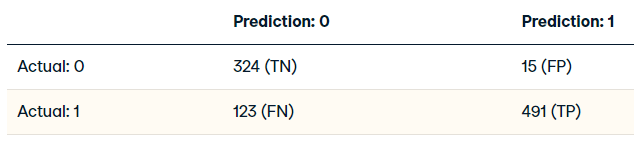

- Use the confusion matrix to calculate overall accuracy.

```python
# Assigning values:
TP, TN, FP, FN = 491, 324, 15, 123
```

```python
# Calculating accuracy:
accuracy = (TP + TN) / (TP + TN + FP + FN)
```

- Use the confusion matrix to calculate precision and recall.

```python
# Calculating precision:
precision = TP / (TP + FP)
```

```python
# Calculating recall:
recall = TP / (TP + FN)
```

- Use the three print statements to print each accuracy value.

```python
# Printing accuracy, precision & recall:
print(f"The overall accuracy is {accuracy:.2f}")
print(f"The precision is {precision:.2f}")
print(f"The recall is {recall:.2f}")
```

```
The overall accuracy is 0.86
The precision is 0.97
The recall is 0.80
```

### 3.2. Confusion matrices, again

Creating a confusion matrix in Python is simple. The biggest challenge will be making sure you understand the orientation of the matrix. This exercise makes sure you understand the `sklearn` implementation of confusion matrices. Here, you have created a random forest model using the `tic_tac_toe` dataset `rfc` to predict outcomes of 0 (loss) or 1 (a win) for Player One.

Note: If you read about confusion matrices on another website or for another programming language, the values might be reversed.

- Geting everything ready.

```python
# Reading the data:
tic_tac_toe = pd.read_csv("./data/tic-tac-toe.csv")
```

```python
# Exploring the data shape:
tic_tac_toe.shape
```

```
(958, 10)
```

```python
# Exploring the first 5 rows:
tic_tac_toe.head()
```

|  | Top-Left | Top-Middle | Top-Right | Middle-Left | Middle-Middle | Middle-Right | Bottom-Left | Bottom-Middle | Bottom-Right | Class |
| --- | --- | --- | --- | --- | --- | --- | --- | --- | --- | --- |
| 0 | x | x | x | x | o | o | x | o | o | positive |
| 1 | x | x | x | x | o | o | o | x | o | positive |
| 2 | x | x | x | x | o | o | o | o | x | positive |
| 3 | x | x | x | x | o | o | o | b | b | positive |
| 4 | x | x | x | x | o | o | b | o | b | positive |

```python
# Encoding the target column into (0 / 1):
tic_tac_toe['Class'] = tic_tac_toe['Class'].apply(lambda x : 1 if x == 'positive' else 0)
```

```python
# Encoding the feaatures into (0 / 1):
features = [col for col in tic_tac_toe.columns if col != 'Class']
tic_tac_toe = pd.get_dummies(data=tic_tac_toe, columns=features)
```

```python
# Slpitting the data into features matrix (X) & target column (y):
X, y = split_data(tic_tac_toe, 'Class')
```

```python
# Splitting the data into training & hold-out sets:
X_train, X_test, y_train, y_test = train_test_split(X, y, test_size=863, random_state=1111)
```

```python
# Getting the model params from datacamp workspace:
params = {'bootstrap': True, 'ccp_alpha': 0.0, 'class_weight': None, 'criterion': 'gini',
          'max_depth': None, 'max_features': 'auto', 'max_leaf_nodes': None,
          'max_samples': None, 'min_impurity_decrease': 0.0, 'min_samples_leaf': 1,
          'min_samples_split': 2, 'min_weight_fraction_leaf': 0.0, 'n_estimators': 500,
          'n_jobs': None, 'oob_score': False, 'random_state': 1111, 'verbose': 0, 'warm_start': False}
```

```python
# Initializing & fitting the model:
rfc = RandomForestClassifier(**params)
rfc.fit(X_train, y_train)
```

```
RandomForestClassifier(n_estimators=500, random_state=1111)
```

- Import `sklearn`'s function for creating confusion matrices.

> Done
- Using the model `rfc`, create category predictions on the test set `X_test`.

```python
# Making predictions necessary for model evaluation:
test_predictions = rfc.predict(X_test)
```

```python
# Getting the model confusion matrix:
cm = confusion_matrix(y_test, test_predictions)
cm
```

```
array([[177, 123],
       [ 92, 471]], dtype=int64)
```

```python
# Printing TPs:
print(f"The number of true positives is: {cm[1, 1]}")
```

```
The number of true positives is: 471
```

### 3.3. Precision vs. recall

The accuracy metrics you use to evaluate your model should always be based on the specific application. For this example, let's assume you are a really sore loser when it comes to playing Tic-Tac-Toe, but only when you are certain that you are going to win.

Choose the most appropriate accuracy metric, either precision or recall, to complete this example. But remember, if you think you are going to win, you better win!

Use `rfc`, which is a random forest classification model built on the `tic_tac_toe` dataset.

- Import the precision or the recall metric for sklearn. Only one method is correct for the given context.

> Done
- Calculate the precision or recall using y_test for the true values and test_predictions for the predictions.

```python
# Calculating precision:
score = precision_score(y_test, test_predictions)
```

- Print the final score based on your selected metric.

```python
# Printing precision score:
print(f"The precision value is {score:.2f}")
```

```
The precision value is 0.79
```

### 4.1. Error due to under/over-fitting

The candy dataset is prime for overfitting. With only 85 observations, if you use 20% for the testing dataset, you are losing a lot of vital data that could be used for modeling. Imagine the scenario where most of the chocolate candies ended up in the training data and very few in the holdout sample. Our model might only see that chocolate is a vital factor, but fail to find that other attributes are also important. In this exercise, you'll explore how using too many features (columns) in a random forest model can lead to overfitting.

A feature represents which columns of the data are used in a decision tree. The parameter `max_features` limits the number of features available.

- Getting everything ready.

```python
# Reading the data:
candy = pd.read_csv("./data/candy-data.csv")
```

```python
# Exploring the data shape:
candy.shape
```

```
(85, 13)
```

```python
# Exploring the first 5 rows:
candy.head()
```

|  | competitorname | chocolate | fruity | caramel | peanutyalmondy | nougat | crispedricewafer | hard | bar | pluribus | sugarpercent | pricepercent | winpercent |
| --- | --- | --- | --- | --- | --- | --- | --- | --- | --- | --- | --- | --- | --- |
| 0 | 100 Grand | 1 | 0 | 1 | 0 | 0 | 1 | 0 | 1 | 0 | 0.732 | 0.860 | 66.971725 |
| 1 | 3 Musketeers | 1 | 0 | 0 | 0 | 1 | 0 | 0 | 1 | 0 | 0.604 | 0.511 | 67.602936 |
| 2 | One dime | 0 | 0 | 0 | 0 | 0 | 0 | 0 | 0 | 0 | 0.011 | 0.116 | 32.261086 |
| 3 | One quarter | 0 | 0 | 0 | 0 | 0 | 0 | 0 | 0 | 0 | 0.011 | 0.511 | 46.116505 |
| 4 | Air Heads | 0 | 1 | 0 | 0 | 0 | 0 | 0 | 0 | 0 | 0.906 | 0.511 | 52.341465 |

```python
# Dropping the first column:
candy.drop(columns='competitorname', inplace=True)
```

```python
# Splitting the data into feature matrix (X) & target column (y):
X, y = split_data(candy, 'winpercent')
```

```python
# Splitting the data into training & hold-out sets:
X_train, X_test, y_train, y_test = train_test_split(X, y, test_size=17, random_state=1111)
```

- Create a random forest model with 25 trees, a random state of 1111, and max_features of 2. Read the print statements.

```python
# Initializing & fitting the model:
rfr = RandomForestRegressor(n_estimators=25, random_state=1111, max_features=2)
rfr.fit(X_train, y_train)
```

```
RandomForestRegressor(max_features=2, n_estimators=25, random_state=1111)
```

```python
# Printing the training and testing accuracy scores:
print(f"The training error is {mae(y_train, rfr.predict(X_train)):.2f}")
print(f"The testing error is {mae(y_test, rfr.predict(X_test)):.2f}")
```

```
The training error is 3.90
The testing error is 9.15
```

- Set max_features to 11 (the number of columns in the dataset). Read the print statements.

```python
# Initializing & fitting the model:
rfr = RandomForestRegressor(n_estimators=25, random_state=1111, max_features=11)
rfr.fit(X_train, y_train)
```

```
RandomForestRegressor(max_features=11, n_estimators=25, random_state=1111)
```

```python
# Printing the training and testing accuracy scores:
print(f"The training error is {mae(y_train, rfr.predict(X_train)):.2f}")
print(f"The testing error is {mae(y_test, rfr.predict(X_test)):.2f}")
```

```
The training error is 3.59
The testing error is 10.00
```

- Set max_features equal to 4. Read the print statements.

```python
# Initializing & fitting the model:
rfr = RandomForestRegressor(n_estimators=25, random_state=1111, max_features=4)
rfr.fit(X_train, y_train)
```

```
RandomForestRegressor(max_features=4, n_estimators=25, random_state=1111)
```

```python
# Printing the training and testing accuracy scores:
print(f"The training error is {mae(y_train, rfr.predict(X_train)):.2f}")
print(f"The testing error is {mae(y_test, rfr.predict(X_test)):.2f}")
```

```
The training error is 3.60
The testing error is 8.79
```

### 4.2. Am I underfitting?

You are creating a random forest model to predict if you will win a future game of Tic-Tac-Toe. Using the `tic_tac_toe` dataset, you have created training and testing datasets, `X_train`, `X_test`, `y_train`, and `y_test`.

You have decided to create a bunch of random forest models with varying amounts of trees (1, 2, 3, 4, 5, 10, 20, and 50). The more trees you use, the longer your random forest model will take to run. However, if you don't use enough trees, you risk underfitting. You have created a for loop to test your model at the different number of trees.

- For each loop, predict values for both the X_train and X_test datasets.
- For each loop, append the accuracy_score() of the y_train dataset and the corresponding predictions to train_scores.
- For each loop, append the accuracy_score() of the y_test dataset and the corresponding predictions to test_scores.
- Print the training and testing scores using the print statements.

```python
# Slpitting the data into features matrix (X) & target column (y):
X, y = split_data(tic_tac_toe, 'Class')
```

```python
# Splitting the data into training & hold-out sets:
X_train, X_test, y_train, y_test = train_test_split(X, y, test_size=192, random_state=1111)
```

```python
train_scores, test_scores = [], []

for i in [1, 2, 3, 4, 5, 10, 20, 50]:

    rfc = RandomForestClassifier(n_estimators=i, random_state=1111)
    rfc.fit(X_train, y_train)

    # Making predictions for X_train and X_test datasets.
    train_predictions = rfc.predict(X_train)
    test_predictions = rfc.predict(X_test)

    # Appending the accuracy score for test and train predictions.
    train_scores.append(round(accuracy_score(y_train, train_predictions), 2))
    test_scores.append(round(accuracy_score(y_test, test_predictions), 2))

# Printing the train and test scores:
print(f"The training scores were: {train_scores}")
print(f"The testing scores were: {test_scores}")
```

```
The training scores were: [0.94, 0.93, 0.98, 0.97, 0.99, 1.0, 1.0, 1.0]
The testing scores were: [0.83, 0.79, 0.89, 0.91, 0.91, 0.93, 0.97, 0.98]
```